# SP_25__GL

## Групове заняття 14

### Тема 2: Обробка масивів даних. Машинне навчання з учителем

### Заняття 25: Класифікація текстових повідомлень

### Результати заняття

*(слухач зможе)*

**НАВЧАЛЬНИЙ ЧАС**: 2 години.

**Навчальна література:**

1. The Python Tutorial [Електронний ресурс] – Режим доступу до ресурсу: https://docs.python.org/3/tutorial/index.html.
2. Pandas. Working with text data [Електронний ресурс] – Режим доступу до ресурсу: https://pandas.pydata.org/docs/user_guide/text.html
3. Ukrainian-Stopwords [Електронний ресурс] – Режим доступу до ресурсу: https://github.com/skupriienko/Ukrainian-Stopwords

### ПЛАН ЗАНЯТТЯ

| № з/п | Навчальні питання | Час, хв |
| --- | --- | --- |
| 1 | **ВСТУПНА ЧАСТИНА** | 5 |
| 2 | **ОСНОВНА ЧАСТИНА** | 80 |
| 2.1 | Підготовка даних та попередній аналіз корпусу текстів | 40 |
| 2.2 | Створення моделі машинного навчання | 40 |
| 3 | **ЗАКЛЮЧНА ЧАСТИНА** | 5 |

### Навчальне питання 1. Підготовка даних та попередній аналіз корпусу текстів

*Теорія - 20 хв, практика - 20 хв*

Важливим етапом будь-якого дослідження є попередній аналіз. Це дозволяє вірно визначити подальші дії та й взагалі стратегію роботи з даними. Для прикладу, розглянемо вибірку з коментарями про кандидата на виборну посаду та уже проведеної обробки з віднесенням до тематики, та емоційною оцінкою.

Вибірку такого типу називають - **розмічені дані**. Розмічені дані, в залежності від інструменту, який застосовувався, можуть зберігатися у різних форматах. Одні із них можуть бути одразу прочитані та завантажені у датафрейм, інші - потребують підготовки.

Застосовуючи підхід запропонований на попередньому занятті, проведемо аналіз наданих даних.

#### Послідовність дій

```
flowchart TD
    A>"Перегляд та аналіз даних у файлі"]
    B>"Формування структури даних"]
    C>"Виявлення та видалення зайвої інформації"]
    D>"Розробка та застосування циклічного алгоритму"]
    A ==> B
    B ==> C
    C ==> D
```

Перегляд файлу здійснюється за допомогою будь-якого системного редактору.

```python
# Підготовка даних для класифікації текстових повідомлень

import re
from pprint import pprint

data = []
with open('data_president.txt', 'r', encoding='utf-8') as f:
    obj = {'text': '', 'sentiment': '', 'theme': ''}
    for line in f.readlines():
        if re.match(r'^\d{1,2}. Текст: ', line):
            txt = re.match(r'^\d{1,2}. Текст: "(.*)"', line)
            obj['text'] = txt.group(1)
        elif re.match(r'^Розмітка: {', line.strip()):
            match_markup = re.match(r'^Розмітка: {.*"настрій": "(.*)", "тема": "(.*)"}', line.strip())
            if match_markup:
                sentiment = match_markup.group(1)
                theme = match_markup.group(2)
                obj['sentiment'] = sentiment
                obj['theme'] = theme
                data.append(obj)
                obj = {'text': '', 'sentiment': '', 'theme': ''}

pprint(data)
```

```
[{'sentiment': 'позитивний',
  'text': 'Кандидат має чітке бачення майбутнього країни.',
  'theme': 'лідерство'},
 {'sentiment': 'нейтральний',
  'text': 'Його економічна програма викликає багато запитань.',
  'theme': 'економіка'},
 {'sentiment': 'негативний',
  'text': 'Я не підтримую його підхід до зовнішньої політики.',
  'theme': 'зовнішня політика'},
 {'sentiment': 'позитивний',
  'text': 'Його обіцянки щодо реформ виглядають дуже амбітними.',
  'theme': 'реформи'},
 {'sentiment': 'негативний',
  'text': 'Кандидат не має достатнього досвіду для управління країною.',
  'theme': 'досвід'},
 {'sentiment': 'змішаний',
  'text': 'Його промова була натхненною, але не дуже конкретною.',
  'theme': 'комунікація'},
 {'sentiment': 'позитивний',
  'text': 'Його підхід до освіти заслуговує на увагу.',
  'theme': 'освіта'},
 {'sentiment': 'негативний',
  'text': "Обіцянки кандидата щодо охорони здоров'я виглядають недостатньо "
          'реалістичними.',
  'theme': "охорона здоров'я"},
 {'sentiment': 'змішаний',
  'text': 'Він має харизму, але його плани не переконують.',
  'theme': 'лідерство'},
 {'sentiment': 'позитивний',
  'text': 'Його екологічна програма є важливим кроком вперед.',
  'theme': 'екологія'},
 {'sentiment': 'позитивний',
  'text': 'Його заяви щодо реформ у судовій системі вселяють надію.',
  'theme': 'судова реформа'},
 {'sentiment': 'негативний',
  'text': 'Кандидат уникає відповідей на складні питання.',
  'theme': 'комунікація'},
 {'sentiment': 'позитивний',
  'text': 'Його ідеї щодо економічного розвитку є дуже цікавими.',
  'theme': 'економіка'},
```

[output cut: 62 more lines]

```
 {'sentiment': 'негативний',
  'text': 'Його заяви щодо міжнародної торгівлі викликають занепокоєння.',
  'theme': 'міжнародна торгівля'},
 {'sentiment': 'позитивний',
  'text': 'Його участь у благодійних ініціативах є прикладом для інших.',
  'theme': 'благодійність'},
 {'sentiment': 'негативний',
  'text': 'Його економічна стратегія виглядає недостатньо продуманою.',
  'theme': 'економіка'},
 {'sentiment': 'позитивний',
  'text': 'Його обіцянки щодо підтримки фермерів є дуже важливими.',
  'theme': 'сільське господарство'},
 {'sentiment': 'змішаний',
  'text': 'Його позиція щодо свободи слова є суперечливою.',
  'theme': 'свобода слова'}]
```

Підготовлені дані тепер можуть бути використані для створення датафрейму.

```python
import pandas as pd
import seaborn as sns
import matplotlib.pyplot as plt

# Load the data
df = pd.DataFrame(data)
df.head()
```

|  | text | sentiment | theme |
| --- | --- | --- | --- |
| 0 | Кандидат має чітке бачення майбутнього країни. | позитивний | лідерство |
| 1 | Його економічна програма викликає багато запит... | нейтральний | економіка |
| 2 | Я не підтримую його підхід до зовнішньої політ... | негативний | зовнішня політика |
| 3 | Його обіцянки щодо реформ виглядають дуже амбі... | позитивний | реформи |
| 4 | Кандидат не має достатнього досвіду для управл... | негативний | досвід |

Реалізуємо швидкий аналіз даних

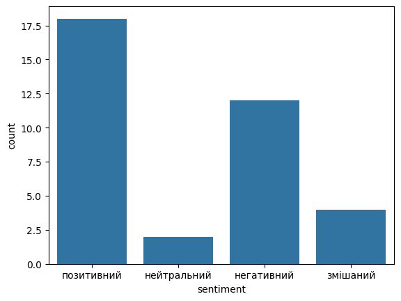

```python
sns.countplot(data=df, x='sentiment')
plt.show()
```

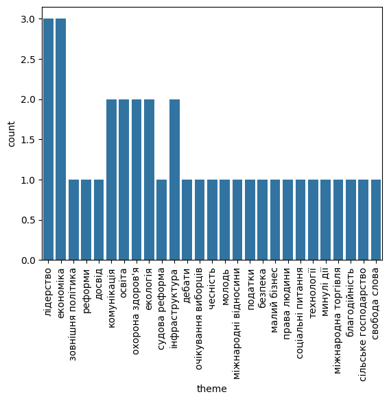

```python
sns.countplot(data=df, x='theme')
plt.xticks(rotation=90)
plt.show()
```

Проведемо дослідження, які із цих тематик мають найбільше позитивних відгуків

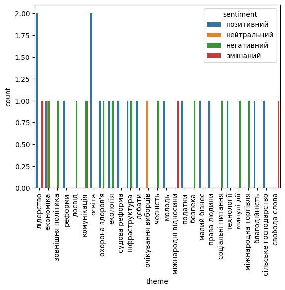

```python
sns.countplot(data=df, x='theme', hue='sentiment')
plt.xticks(rotation=90)
plt.show()
```

> **Практичне завдання 1**

> За наданим прикладом:
> 1. згенеруйте масив розмічених даних
> 2. завантажте файл та сформуйте `dataframe`
> 3. проаналізуйте отримані дані
> 4. внесіть пропущені дані, та прийміть рішення щодо таких рядків

### Навчальне питання 2. Створення моделі машинного навчання

*Теорія - 20 хв, практика - 20 хв*

Розглянемо підготовку даних для побудови моделі машинного навчання. Для цього виберемо у якості ознаки - текст коментаря (*feature variable*), а у якості цільової змінної - настрій коментаря (*target variable*).

```python
target_data = df[['sentiment', 'text']]
target_data
```

|  | sentiment | text |
| --- | --- | --- |
| 0 | позитивний | Кандидат має чітке бачення майбутнього країни. |
| 1 | нейтральний | Його економічна програма викликає багато запит... |
| 2 | негативний | Я не підтримую його підхід до зовнішньої політ... |
| 3 | позитивний | Його обіцянки щодо реформ виглядають дуже амбі... |
| 4 | негативний | Кандидат не має достатнього досвіду для управл... |
| 5 | змішаний | Його промова була натхненною, але не дуже конк... |
| 6 | позитивний | Його підхід до освіти заслуговує на увагу. |
| 7 | негативний | Обіцянки кандидата щодо охорони здоров'я вигля... |
| 8 | змішаний | Він має харизму, але його плани не переконують. |
| 9 | позитивний | Його екологічна програма є важливим кроком впе... |
| 10 | позитивний | Його заяви щодо реформ у судовій системі вселя... |
| 11 | негативний | Кандидат уникає відповідей на складні питання. |
| 12 | позитивний | Його ідеї щодо економічного розвитку є дуже ці... |
| 13 | негативний | Плани щодо інфраструктури виглядають нереальними. |
| 14 | позитивний | Його участь у дебатах показала його впевненіст... |
| 15 | нейтральний | Виборці вимагають більш конкретних рішень від ... |
| 16 | позитивний | Я підтримую його, оскільки він пропонує реаліс... |
| 17 | негативний | Його участь у попередніх політичних кампаніях ... |
| 18 | позитивний | Мені подобається, що він активно залучає молод... |
| 19 | змішаний | Його позиція щодо міжнародних відносин є трохи... |
| 20 | позитивний | Його обіцянки щодо зниження податків виглядают... |
| 21 | негативний | Він не надав чітких відповідей щодо питань без... |
| 22 | позитивний | Його ініціативи щодо підтримки малого бізнесу ... |
| 23 | позитивний | Його позиція щодо прав людини є дуже прогресив... |
| 24 | негативний | Він уникає обговорення важливих соціальних пит... |
| 25 | позитивний | Його пропозиції щодо інновацій у технологіях в... |
| 26 | негативний | Його минулі дії викликають сумніви у виборців. |
| 27 | позитивний | Його обіцянки щодо покращення інфраструктури в... |
| 28 | негативний | Його підхід до вирішення екологічних проблем є... |
| 29 | позитивний | Він демонструє сильне лідерство у кризових сит... |
| 30 | позитивний | Його пропозиції щодо реформ у системі охорони ... |
| 31 | негативний | Його заяви щодо міжнародної торгівлі викликают... |
| 32 | позитивний | Його участь у благодійних ініціативах є прикла... |
| 33 | негативний | Його економічна стратегія виглядає недостатньо... |
| 34 | позитивний | Його обіцянки щодо підтримки фермерів є дуже в... |
| 35 | змішаний | Його позиція щодо свободи слова є суперечливою. |

```python
X = target_data['text']   # feature variable
y = target_data['sentiment']    # target variable
```

Розділяємо дані на тестові та ті що будуть використані під час навчання

```python
from sklearn.model_selection import train_test_split

X_train, X_test, y_train, y_test = train_test_split(X, y, test_size=0.2, random_state=42)
```

Доцільно відкрити документацію для train_test_split та скопіювати спосіб застосування цього методу help(train_test_split)

```python
from sklearn.feature_extraction.text import TfidfVectorizer

stop_words = []
with open('stopwords_ua.txt', 'r', encoding='utf-8') as f:
    stop_words = [line.strip() for line in f.readlines()]

vectorizer = TfidfVectorizer(stop_words=stop_words) # Створюємо об'єкт векторизатора
vectorizer.fit(X_train)

X_train_tfidf = vectorizer.transform(X_train) # Трансформуємо навчальну вибірку
X_test_tfidf = vectorizer.transform(X_test) # Трансформуємо тестову вибірку

X_train_tfidf
```

```
<Compressed Sparse Row sparse matrix of dtype 'float64'
	with 137 stored elements and shape (28, 112)>
```

Застосуємо модель на основі `наївного Баєса`

```python
from sklearn.naive_bayes import MultinomialNB

model_NB = MultinomialNB()
model_NB.fit(X_train_tfidf, y_train)  # Навчаємо модель
```

```
MultinomialNB()
```

Застосуємо модель на основі `логістичної регресії`

```python
from sklearn.linear_model import LogisticRegression

model_LR = LogisticRegression(max_iter=1000)
model_LR.fit(X_train_tfidf, y_train)  # Навчаємо модель
```

```
LogisticRegression(max_iter=1000)
```

Для оцінювання якості роботи обраної моделі бібліотека `sklearn` має також інструменти

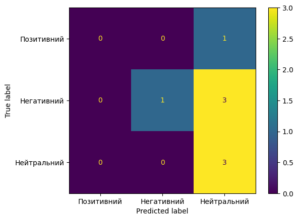

```python
from sklearn.metrics import confusion_matrix, ConfusionMatrixDisplay
import matplotlib.pyplot as plt

predictions_NB = model_NB.predict(X_test_tfidf)
cm = confusion_matrix(y_test, predictions_NB)
showCM = ConfusionMatrixDisplay(confusion_matrix=cm,
    display_labels=['Позитивний', 'Негативний', 'Нейтральний'])
showCM.plot(cmap='viridis');
```

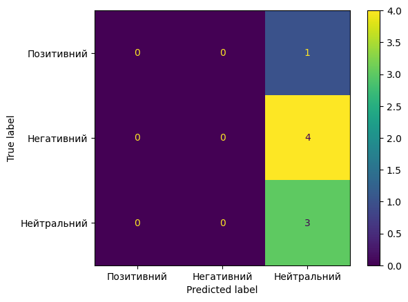

```python
predictions_LR = model_LR.predict(X_test_tfidf)
cm_LR = confusion_matrix(y_test, predictions_LR)
showCM_LR = ConfusionMatrixDisplay(confusion_matrix=cm_LR,
    display_labels=['Позитивний', 'Негативний', 'Нейтральний'])
showCM_LR.plot(cmap='viridis');
```

На основі аналізу метрик приймається рішення щодо доцільності тієї чи іншої моделі.

Для того щоб взяти модель у роботу використовують також інструменти бібліотеки `sklearn`

```python
from sklearn.pipeline import Pipeline

pipeline_NB = Pipeline([
    ('tfidf', TfidfVectorizer(stop_words=stop_words)),
    ('classifier', MultinomialNB())
])

pipeline_lr = Pipeline([
    ('tfidf', TfidfVectorizer(stop_words=stop_words)),
    ('classifier', LogisticRegression(max_iter=1000))
])
```

Але перед використанням, доцільно провести навчання моделі над усіма даними

```python
# Навчаємо модель на всіх даних
pipeline_NB.fit(X, y) # варіант для наївного Баєса
pipeline_lr.fit(X, y) # варіант для логістичної регресії
```

```
Pipeline(steps=[('tfidf',
                 TfidfVectorizer(stop_words=['а', 'аби', 'абиде', 'абиким',
                                             'абикого', 'абиколи', 'абикому',
                                             'абикуди', 'абихто', 'абичий',
                                             'абичийого', 'абичийому', 'абичим',
                                             'абичию', 'абичия', 'абичиє',
                                             'абичиєму', 'абичиєю', 'абичиєї',
                                             'абичиї', 'абичиїй', 'абичиїм',
                                             'абичиїми', 'абичиїх', 'абичого',
                                             'абичому', 'абищо', 'абияка',
                                             'абияке', 'абиякий', ...])),
                ('classifier', LogisticRegression(max_iter=1000))])
```

Для використання моделей нові коментарі записуються як елементи списку

```python
pipeline_NB.predict(['досвіду немає!'])
```

```
array(['негативний'], dtype='<U11')
```

```python
pipeline_lr.predict(['проблем немає!'])
```

```
array(['позитивний'], dtype=object)
```

> **Практичне завдання 2**

> Відповідно до створеного `dataframe` у першому практичному:
> 1. Сформуйте моделі
> 2. Перевірте їх адекватність
> 3. Сформуйте та підготуйте отриману модель до роботи